# Integración de HTML y RMarkdown

Pablo Marin

2024-10-22

# Tarea#3: Integración de HTML y RMarkdown

## Objetivo

El objetivo de este informe es poner en práctica lo que hemos aprendido sobre HTML y RMarkdown, combinando ambas herramientas para crear un informe en formato HTML. A través de este proyecto, podremos generar un análisis sencillo en R, incluyendo gráficos y cálculos, y luego enriquecer el informe añadiendo componentes interactivos de HTML. Esta tarea nos permitirá aplicar de manera integrada los conceptos de programación y visualización de datos, con el fin de mejorar tanto la presentación como la comprensión de la información.

Análisis simple en R que incluya lo siguiente:

- Crear un vector con los números del 1 al 10.

  ```r
  vector <- c(1:10)#Se crea variable vector con valores del 1 al 10
  print(vector)# Se imprime variable vector
  ```

  ```
  ##  [1]  1  2  3  4  5  6  7  8  9 10
  ```

- Calcular la media y la suma de los valores del vector.
  - Media Vector

    ```r
    print(mean(vector)) #Mostramos en pantalla el resultado de llamar la funcion mean para la variable vector
    ```

    ```
    ## [1] 5.5
    ```

  - Suma Vector

    ```r
    print(sum(vector)) #Mostramos en pantalla el resultado de sumar los varoles del vector
    ```

    ```
    ## [1] 55
    ```

- Incluir un gráfico sencillo utilizando la función plot() para graficar el vector.

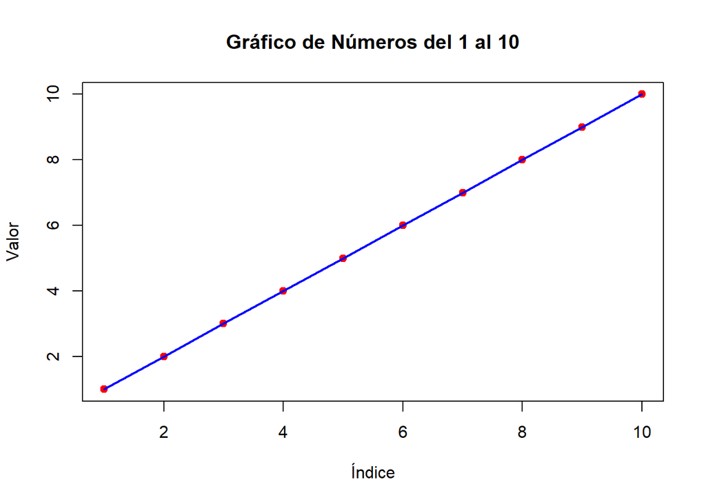

```r
#Generamos con los valores del vertor un grafico con plot()

plot(vector,
     main = "Gráfico de Números del 1 al 10",
     xlab = "Índice",
     ylab = "Valor",
     col = "red",
     pch = 19)

#Le colocamo una linea que conecta los puntos

lines(vector, col = "blue", lwd = 2)
```

Integración de componentes HTML

Enlace a Google

[Visita Google](https://www.google.com)

Imagen de grafico

[figure not shown]

Elementos relacionados con análisis de datos

- Análisis descriptivo
- Visualización de datos
- Modelado predictivo

Formulario para envio de correo

Nombre:  
Correo electrónico: